# My first project

Wang

05/07/2019

## R Markdown

The data for this assignment can be downloaded from the course web site:

Dataset: Activity monitoring data [52K] The variables included in this dataset are:

steps: Number of steps taking in a 5-minute interval (missing values are coded as NA) date: The date on which the measurement was taken in YYYY-MM-DD format interval: Identifier for the 5-minute interval in which measurement was taken.

1. Getting and reading the data

```r
if (!"file.zip" %in% dir()){
url <- "https://d396qusza40orc.cloudfront.net/repdata%2Fdata%2Factivity.zip"
download.file(url, destfile = "file.zip")
unzip("file.zip", exdir = "data")
}
filepath <- paste(getwd(), "data", dir("data")[1], sep = "/")
r <- read.csv(filepath)
```

2. Histogram of the total number of steps taken each day

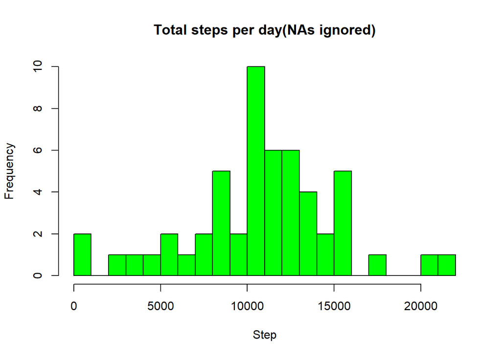

```r
agg <- with(r, aggregate(steps~date, FUN = sum))
hist(agg$steps, breaks = 20, col = "green", main = "Total steps per day(NAs ignored)", xlab = "Step")
```

3. Mean and median number of steps taken each day

```r
data.frame(mean = mean(agg$steps), median = median(agg$steps))
```

```
##       mean median
## 1 10766.19  10765
```

4. Time series plot of the average number of steps taken

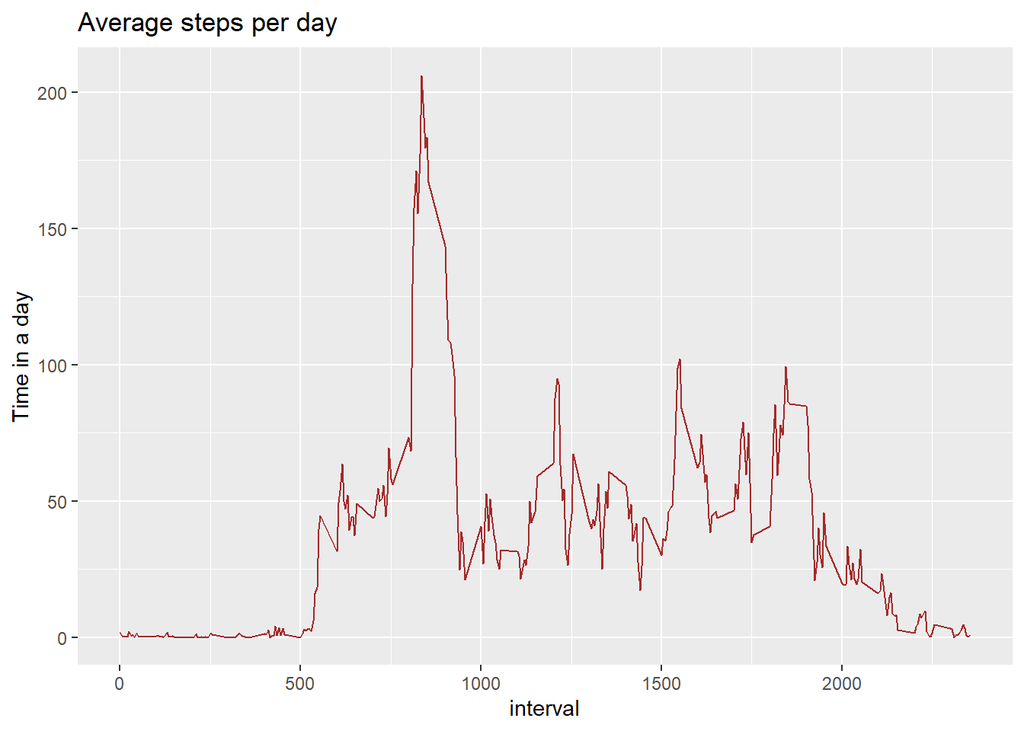

```r
agg2 <- with(r, aggregate(steps~interval, FUN = mean, rm.na = T))
library(ggplot2)
gg <- ggplot(agg2, aes(interval, steps)) + geom_line(col = "brown") +
    labs(y = "Time in a day", title = "Average steps per day")
gg
```

5. The 5-minute interval that, on average, contains the maximum number of steps

```r
agg2[which(agg2$steps == max(agg2$steps, na.rm = T)),]
```

```
##     interval    steps
## 104      835 206.1698
```

6. Code to describe and show a strategy for imputing missing data ## Replace the missing values with the median of the non-missing values which is 0

```r
r1 <- r
r1[is.na(r1$steps),]$steps <- median(r1[!is.na(r1$steps),]$steps)
```

7. Histogram of the total number of steps taken each day after missing values are imputed

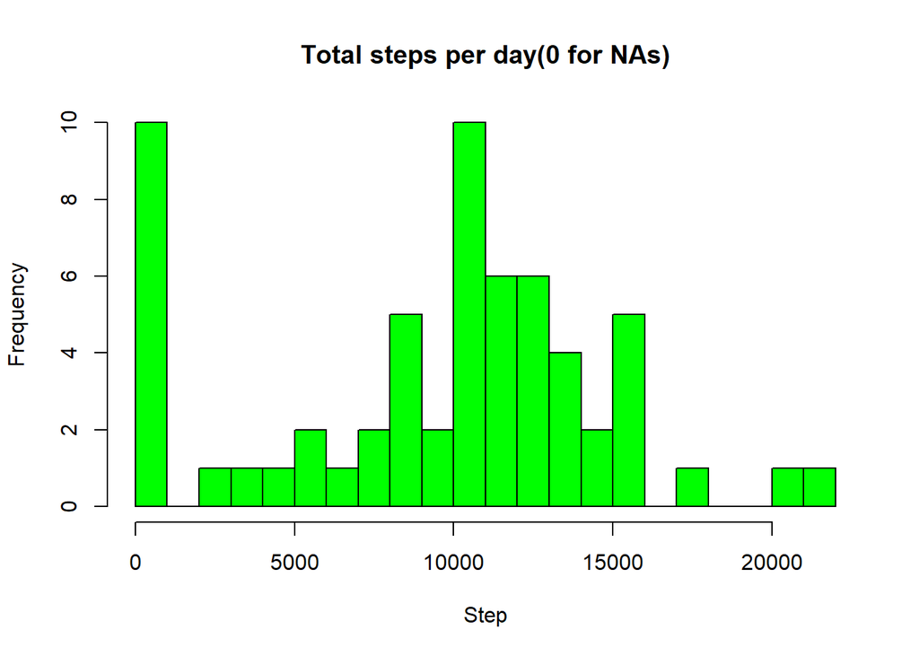

```r
agg3 <- with(r1, aggregate(steps~date, FUN = sum))
hist(agg3$steps, breaks = 20, col = "green", main = "Total steps per day(0 for NAs)", xlab = "Step")
```

```r
r2 <- r
r2$date <- as.POSIXct(r2$date, format = "%Y-%m-%d")
library(dplyr)
```

[figure not shown]

```r
r2.0 <- mutate(r2, "Day_in_a_week" = weekdays(r2$date))
rweekdays <- filter(r2.0, Day_in_a_week=="Monday"|Day_in_a_week=="Tuesday"|Day_in_a_week=="Wednesday"|Day_in_a_week =="Thursday"|Day_in_a_week == "Friday")
rweekends <- filter(r2.0, Day_in_a_week == "Saterday" | Day_in_a_week == "Sunday")
##(1)
agg4 <- with(rweekdays, aggregate(steps~interval, FUN = mean))
##(2)
agg5 <- with(rweekends, aggregate(steps~interval, FUN = mean))
par(mfrow = c(1,2))
with(agg4, plot(steps~interval, type = "l", main = "Weekday", ylim = c(0, 250)))
with(agg5, plot(steps~interval, type = "l", main = "Weekend", ylim = c(0, 250)))
```